# Homework - CIs - Solutions

author: “Del Middlemiss”  
date: “30th August 2019”

# 1 MVP

Now we’ll go back to CI creation in the normal fashion. We’ll take the `ames` data from the CIs lab earlier today and regard it now as a **sample**, we won’t be drawing any smaller samples from within it. This is the usual situation in an analysis: you use all the data available to you!

- Load the data again, `clean_names()`, and re-familiarise yourself with it

```r
library(tidyverse)
library(janitor)
library(infer)
```

```r
ames <- read_csv("data/ames.csv")
ames <- clean_names(ames)
glimpse(ames)
```

```
## Rows: 2,930
## Columns: 82
## $ order           <dbl> 1, 2, 3, 4, 5, 6, 7, 8, 9, 10, 11, 12, 13, 14, 15, 16…
## $ pid             <dbl> 526301100, 526350040, 526351010, 526353030, 527105010…
## $ ms_sub_class    <dbl> 20, 20, 20, 20, 60, 60, 120, 120, 120, 60, 60, 20, 60…
## $ ms_zoning       <chr> "RL", "RH", "RL", "RL", "RL", "RL", "RL", "RL", "RL",…
## $ lot_frontage    <dbl> 141, 80, 81, 93, 74, 78, 41, 43, 39, 60, 75, NA, 63, …
## $ lot_area        <dbl> 31770, 11622, 14267, 11160, 13830, 9978, 4920, 5005, …
## $ street          <chr> "Pave", "Pave", "Pave", "Pave", "Pave", "Pave", "Pave…
## $ alley           <chr> NA, NA, NA, NA, NA, NA, NA, NA, NA, NA, NA, NA, NA, N…
## $ lot_shape       <chr> "IR1", "Reg", "IR1", "Reg", "IR1", "IR1", "Reg", "IR1…
## $ land_contour    <chr> "Lvl", "Lvl", "Lvl", "Lvl", "Lvl", "Lvl", "Lvl", "HLS…
## $ utilities       <chr> "AllPub", "AllPub", "AllPub", "AllPub", "AllPub", "Al…
## $ lot_config      <chr> "Corner", "Inside", "Corner", "Corner", "Inside", "In…
## $ land_slope      <chr> "Gtl", "Gtl", "Gtl", "Gtl", "Gtl", "Gtl", "Gtl", "Gtl…
```

[output cut: 69 more lines]

- Investigate the distribution of `lot_area`. Is the distribution roughly normal? If not, what problems do you find?

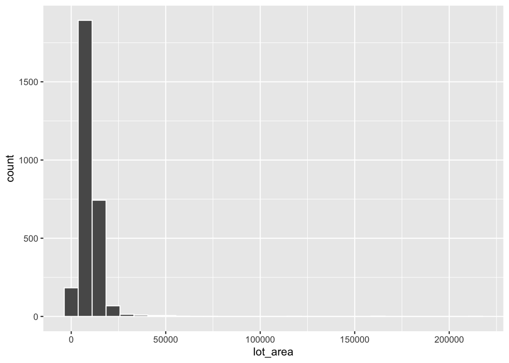

```r
ames %>%
  ggplot(aes(x = lot_area)) +
  geom_histogram(col = "white", bins = 30)
```

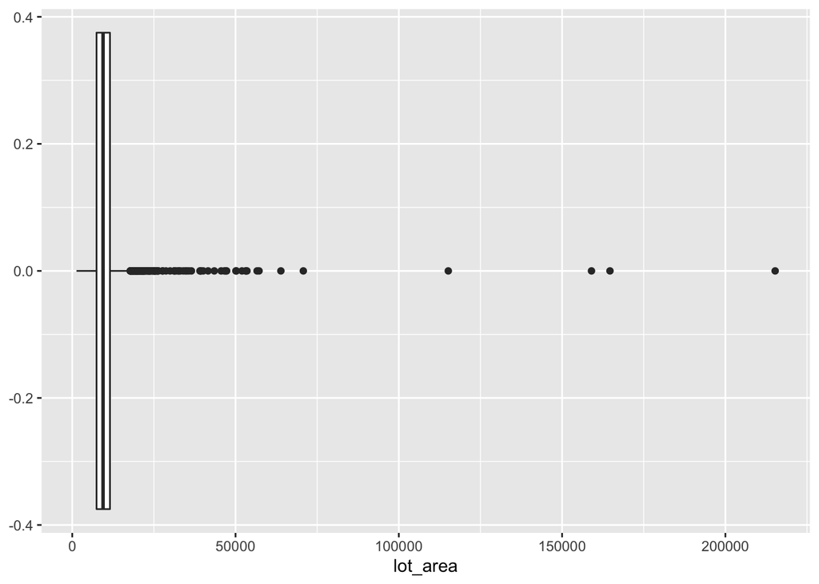

```r
ames %>%
  ggplot(aes(x = lot_area)) +
  geom_boxplot()
```

The main problem is a significant number of high outliers, the distribution is very right-skewed.

- Compute and visualise a bootstrap sampling distribution for the `mean(lot_area)` of the sold houses.

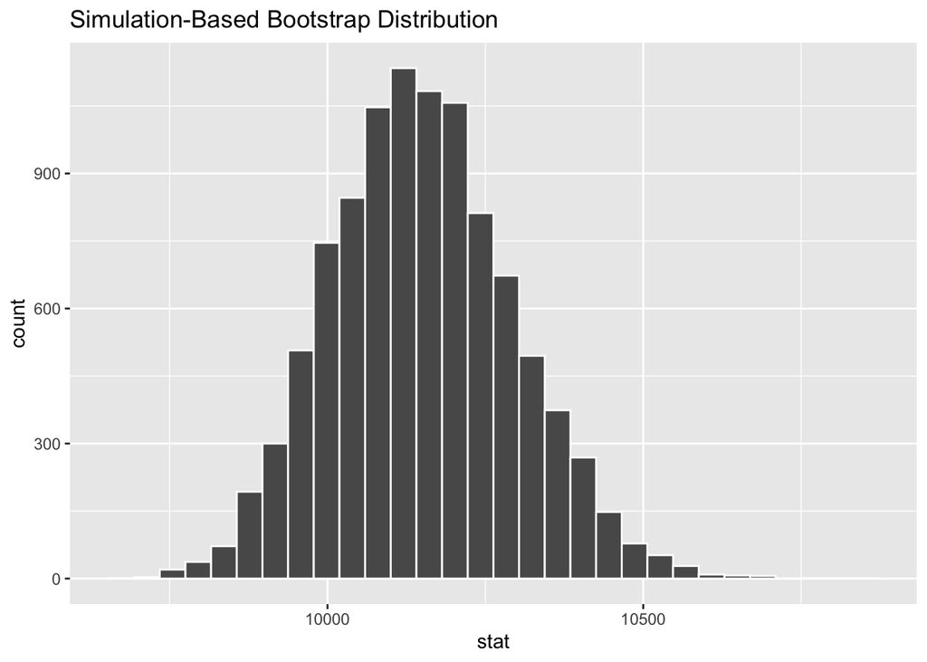

```r
bootstrap_distn <- ames %>%
  specify(response = lot_area) %>%
  generate(reps = 10000, type = "bootstrap") %>%
  calculate(stat = "mean")

bootstrap_distn %>%
  visualise(bins = 30)
```

- Use your bootstrap distribution to calculate a $95\%$ CI for `mean(lot_area)`, and visualise it on the distribution

```r
lot_area_ci95 <- bootstrap_distn %>%
  get_ci(level = 0.95, type = "percentile")
lot_area_ci95
```

| lower_ci | upper_ci |
| --- | --- |
| 9882.805 | 10445.92 |

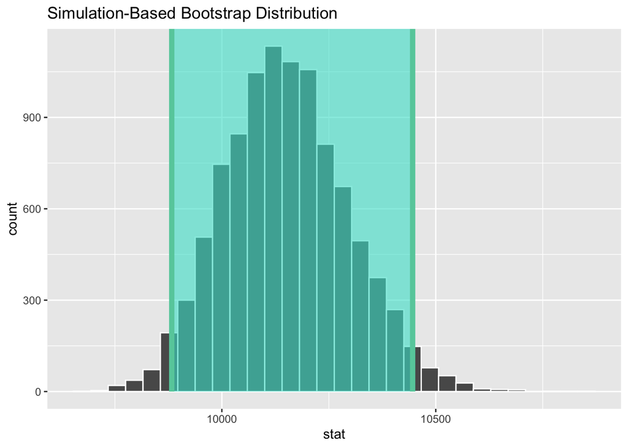

```r
bootstrap_distn %>%
  visualise(bins = 30) +
  shade_ci(endpoints = lot_area_ci95)
```

- You would like to know the `mean(lot_area)` of the sold houses with higher confidence. Calculate the $99\%$ CI for this variable (you can re-use your bootstrap distribution from above). Is it narrower or broader than the $95\%$ CI? Does that make sense?

```r
lot_area_ci99 <- bootstrap_distn %>%
  get_ci(level = 0.99, type = "percentile")
lot_area_ci99
```

| lower_ci | upper_ci |
| --- | --- |
| 9802.997 | 10549.84 |

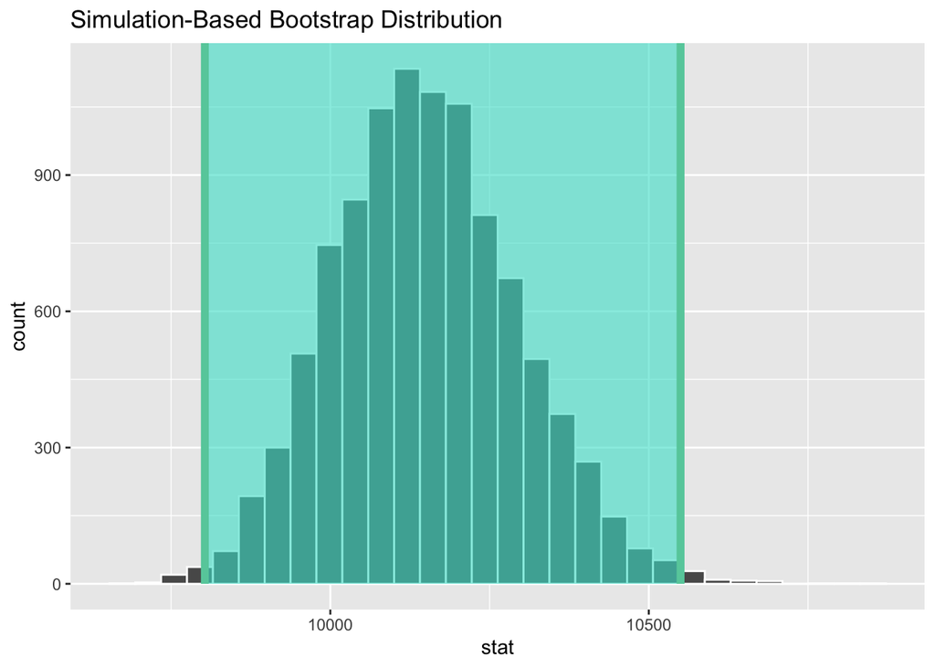

```r
bootstrap_distn %>%
  visualise(bins = 30) +
  shade_ci(endpoints = lot_area_ci99)
```

It is broader than the $95\%$ CI. We haven’t increased sample size, so the only way to increase confidence is by increasing the width of the interval. Again, by analogy: to be more confident of catching the fish, you need to use a bigger net.

- Calculate the point estimate of the `mean(lot_area)`

```r
# either
ames %>%
  summarise(point_est = mean(lot_area))
```

| point_est |
| --- |
| 10147.92 |

```r
# or
bootstrap_distn %>%
  summarise(point_est = mean(stat))
```

| point_est |
| --- |
| 10150.26 |

# 2 Extension

- Calculate a point estimate and $95\%$ CI for the proportion of houses in the data built before 1920. Does the number of `reps` you use matter? [Investigate `reps` from $200$ up to $50000$, memory of your laptop permitting].  
  [**Hint** - the current implementation of `calculate(stat = "prop")` in `infer` is slow! You can get around this by treating the mean in this way: add a new column via `mutate(before_1920 = as.numeric(year_built < 1920))` and then `calculate(stat = "mean")` on this new column]

```r
ames_before_1920 <- ames %>%
  mutate(before_1920 = as.numeric(year_built < 1920))
```

To investigate the effect of number of `reps`, let’s generate five different bootstrap sampling distributions

```r
bootstrap_distn_200 <- ames_before_1920 %>%
  specify(response = before_1920) %>%
  generate(reps = 200, type = "bootstrap") %>%
  calculate(stat = "mean")

bootstrap_distn_1000 <- ames_before_1920 %>%
  specify(response = before_1920) %>%
  generate(reps = 1000, type = "bootstrap") %>%
  calculate(stat = "mean")

bootstrap_distn_10000 <- ames_before_1920 %>%
  specify(response = before_1920) %>%
  generate(reps = 10000, type = "bootstrap") %>%
  calculate(stat = "mean")

bootstrap_distn_30000 <- ames_before_1920 %>%
  specify(response = before_1920) %>%
  generate(reps = 30000, type = "bootstrap") %>%
  calculate(stat = "mean")

bootstrap_distn_50000 <- ames_before_1920 %>%
  specify(response = before_1920) %>%
  generate(reps = 50000, type = "bootstrap") %>%
  calculate(stat = "mean")
```

Calculate point estimates:

```r
point_est <- ames_before_1920 %>%
  summarise(point_est = mean(before_1920))
point_est
```

| point_est |
| --- |
| 0.06006826 |

```r
# or
point_est <- bootstrap_distn_50000 %>%
  summarise(point_est = mean(stat))
point_est
```

| point_est |
| --- |
| 0.06008627 |

Now calculate CI and visualise each distribution

```r
before_1920_ci95_200 <- bootstrap_distn_200 %>%
  get_ci(level = 0.95, type = "percentile")
before_1920_ci95_200
```

| lower_ci | upper_ci |
| --- | --- |
| 0.05255119 | 0.07030717 |

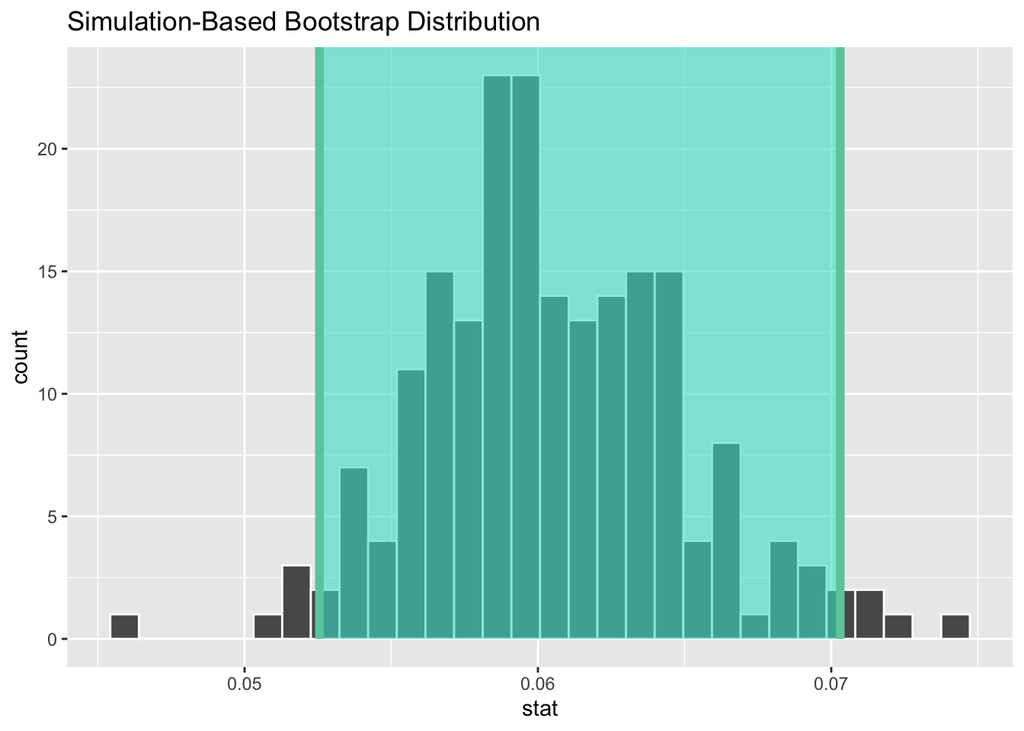

```r
bootstrap_distn_200 %>%
  visualise(bins = 30) +
  shade_ci(endpoints = before_1920_ci95_200)
```

```r
before_1920_ci95_1000 <- bootstrap_distn_1000 %>%
  get_ci(level = 0.95, type = "percentile")
before_1920_ci95_1000
```

| lower_ci | upper_ci |
| --- | --- |
| 0.05051195 | 0.06894198 |

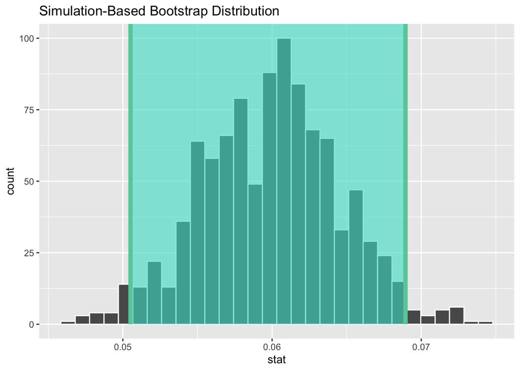

```r
bootstrap_distn_1000 %>%
  visualise(bins = 30) +
  shade_ci(endpoints = before_1920_ci95_1000)
```

```r
before_1920_ci95_10000 <- bootstrap_distn_10000 %>%
  get_ci(level = 0.95, type = "percentile")
before_1920_ci95_10000
```

| lower_ci | upper_ci |
| --- | --- |
| 0.0518686 | 0.06894198 |

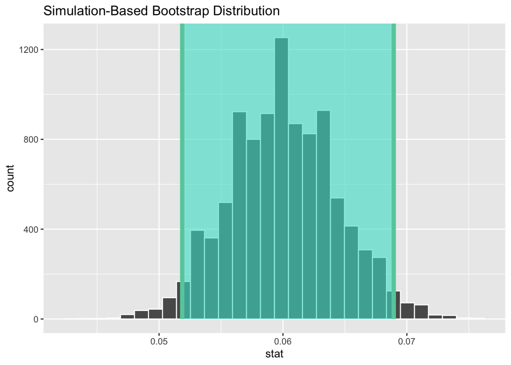

```r
bootstrap_distn_10000 %>%
  visualise(bins = 30) +
  shade_ci(endpoints = before_1920_ci95_10000)
```

```r
before_1920_ci95_30000 <- bootstrap_distn_30000 %>%
  get_ci(level = 0.95, type = "percentile")
before_1920_ci95_30000
```

| lower_ci | upper_ci |
| --- | --- |
| 0.05153584 | 0.06860068 |

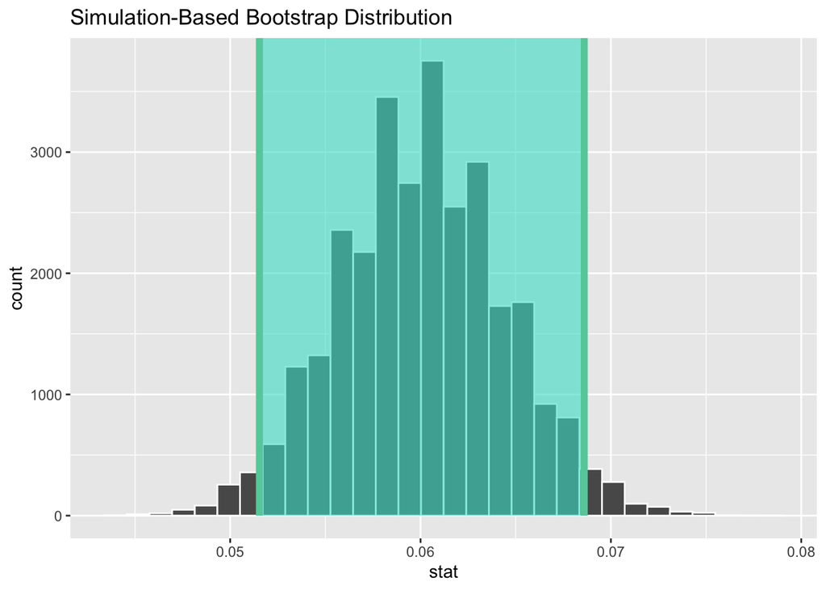

```r
bootstrap_distn_30000 %>%
  visualise(bins = 30) +
  shade_ci(endpoints = before_1920_ci95_30000)
```

```r
before_1920_ci95_50000 <- bootstrap_distn_50000 %>%
  get_ci(level = 0.95, type = "percentile")
before_1920_ci95_50000
```

| lower_ci | upper_ci |
| --- | --- |
| 0.05153584 | 0.06894198 |

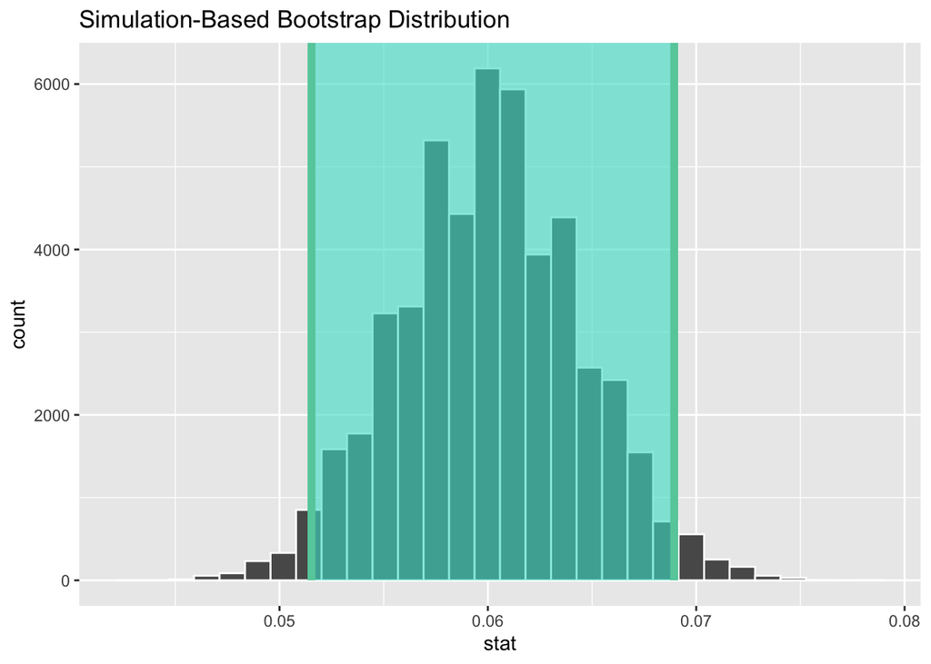

```r
bootstrap_distn_50000 %>%
  visualise(bins = 30) +
  shade_ci(endpoints = before_1920_ci95_50000)
```

CIs calculated using $10,000$ bootstrap repetitions and upward seem more reliable than those using fewer resamplings. You should always test the sensitivity of your calculated CI to number of `reps`!